# Red Wines Analysis by Silvia Onofrei

The dataset contains information about red “Vinho Verde”" wine samples, from the north of Portugal, the details are given in [Cortez et al., 2009]. The goal is to determine which physicochemical attributes are relevant to the quality of the wine.

```
## [1] 1599   13
```

There are 1599 samples of wine and 13 attributes for each sample. There are 11 variables based on physicochemical tests and the remaining one is quality.

```
## 'data.frame':    1599 obs. of  13 variables:
##  $ X                   : int  1 2 3 4 5 6 7 8 9 10 ...
##  $ fixed.acidity       : num  7.4 7.8 7.8 11.2 7.4 7.4 7.9 7.3 7.8 7.5 ...
##  $ volatile.acidity    : num  0.7 0.88 0.76 0.28 0.7 0.66 0.6 0.65 0.58 0.5 ...
##  $ citric.acid         : num  0 0 0.04 0.56 0 0 0.06 0 0.02 0.36 ...
##  $ residual.sugar      : num  1.9 2.6 2.3 1.9 1.9 1.8 1.6 1.2 2 6.1 ...
##  $ chlorides           : num  0.076 0.098 0.092 0.075 0.076 0.075 0.069 0.065 0.073 0.071 ...
##  $ free.sulfur.dioxide : num  11 25 15 17 11 13 15 15 9 17 ...
##  $ total.sulfur.dioxide: num  34 67 54 60 34 40 59 21 18 102 ...
##  $ density             : num  0.998 0.997 0.997 0.998 0.998 ...
##  $ pH                  : num  3.51 3.2 3.26 3.16 3.51 3.51 3.3 3.39 3.36 3.35 ...
##  $ sulphates           : num  0.56 0.68 0.65 0.58 0.56 0.56 0.46 0.47 0.57 0.8 ...
##  $ alcohol             : num  9.4 9.8 9.8 9.8 9.4 9.4 9.4 10 9.5 10.5 ...
##  $ quality             : int  5 5 5 6 5 5 5 7 7 5 ...
```

Input variables (based on physicochemical tests):

1. **fixed acidity** (tartaric acid - g / dm^3), most acids involved with wine or fixed or nonvolatile (do not evaporate readily);
2. **volatile acidity** (acetic acid - g / dm^3), the amount of acetic acid in wine, which at too high of levels can lead to an unpleasant, vinegar taste;
3. **citric acid** (g / dm^3), found in small quantities, citric acid can add ‘freshness’ and flavor to wines;
4. **residual sugar** (g / dm^3), the amount of sugar remaining after fermentation stops, it’s rare to find wines with less than 1 gram/liter and wines with greater than 45 grams/liter are considered sweet;
5. **chlorides** (sodium chloride - g / dm^3), the amount of salt in the wine;
6. **free sulfur dioxide** (mg / dm^3), the free form of SO2 exists in equilibrium between molecular SO2 (as a dissolved gas) and bisulfite ion; it prevents microbial growth and the oxidation of wine;
7. **total sulfur dioxide** (mg / dm^3), amount of free and bound forms of S02; in low concentrations, SO2 is mostly undetectable in wine, but at free SO2 concentrations over 50 ppm, SO2 becomes evident in the nose and taste of wine;
8. **density** (g / cm^3), the density of water is close to that of water depending on the percent alcohol and sugar content;
9. **pH**, describes how acidic or basic a wine is on a scale from 0 (very acidic) to 14 (very basic); most wines are between 3-4 on the pH scale;
10. **sulphates** (potassium sulphate - g / dm^3), a wine additive which can contribute to sulfur dioxide gas (S02) levels, winch acts as an antimicrobial and antioxidant;
11. **alcohol** (% by volume), the percent alcohol content of the wine.

Output variable (based on sensory data):

12. **quality** (score between 0 and 10).

```
##        X          fixed.acidity   volatile.acidity  citric.acid
##  Min.   :   1.0   Min.   : 4.60   Min.   :0.1200   Min.   :0.000
##  1st Qu.: 400.5   1st Qu.: 7.10   1st Qu.:0.3900   1st Qu.:0.090
##  Median : 800.0   Median : 7.90   Median :0.5200   Median :0.260
##  Mean   : 800.0   Mean   : 8.32   Mean   :0.5278   Mean   :0.271
##  3rd Qu.:1199.5   3rd Qu.: 9.20   3rd Qu.:0.6400   3rd Qu.:0.420
##  Max.   :1599.0   Max.   :15.90   Max.   :1.5800   Max.   :1.000
##  residual.sugar     chlorides       free.sulfur.dioxide
##  Min.   : 0.900   Min.   :0.01200   Min.   : 1.00
##  1st Qu.: 1.900   1st Qu.:0.07000   1st Qu.: 7.00
##  Median : 2.200   Median :0.07900   Median :14.00
##  Mean   : 2.539   Mean   :0.08747   Mean   :15.87
##  3rd Qu.: 2.600   3rd Qu.:0.09000   3rd Qu.:21.00
##  Max.   :15.500   Max.   :0.61100   Max.   :72.00
##  total.sulfur.dioxide    density             pH          sulphates
##  Min.   :  6.00       Min.   :0.9901   Min.   :2.740   Min.   :0.3300
##  1st Qu.: 22.00       1st Qu.:0.9956   1st Qu.:3.210   1st Qu.:0.5500
##  Median : 38.00       Median :0.9968   Median :3.310   Median :0.6200
##  Mean   : 46.47       Mean   :0.9967   Mean   :3.311   Mean   :0.6581
##  3rd Qu.: 62.00       3rd Qu.:0.9978   3rd Qu.:3.400   3rd Qu.:0.7300
##  Max.   :289.00       Max.   :1.0037   Max.   :4.010   Max.   :2.0000
##     alcohol         quality
##  Min.   : 8.40   Min.   :3.000
##  1st Qu.: 9.50   1st Qu.:5.000
##  Median :10.20   Median :6.000
##  Mean   :10.42   Mean   :5.636
##  3rd Qu.:11.10   3rd Qu.:6.000
##  Max.   :14.90   Max.   :8.000
```

# Univariate Plots Section

For each of the 11 numerical attributes I plot a frequency histogram with adjusted binwidth and a vertical line corresponding to the mean value of the dataset. I also include the corresponding boxplot. I investigate the existence of (mild) outliers (values which lie between 1.5 times and 3.0 times the interquartile range below the first quartile or above the third quartile) and extreme outliers (values which lie more than 3.0 times the interquartile range below the first quartile or above the third quartile). I compute the standard deviations for the whole data and for the data without outliers. I extract information about the extreme outliers in each case. To get more insight into and better understanding of the shape of the data I also plot density histograms, which I color by count and from which I exclude the extreme outliers.

#### Fixed acidity

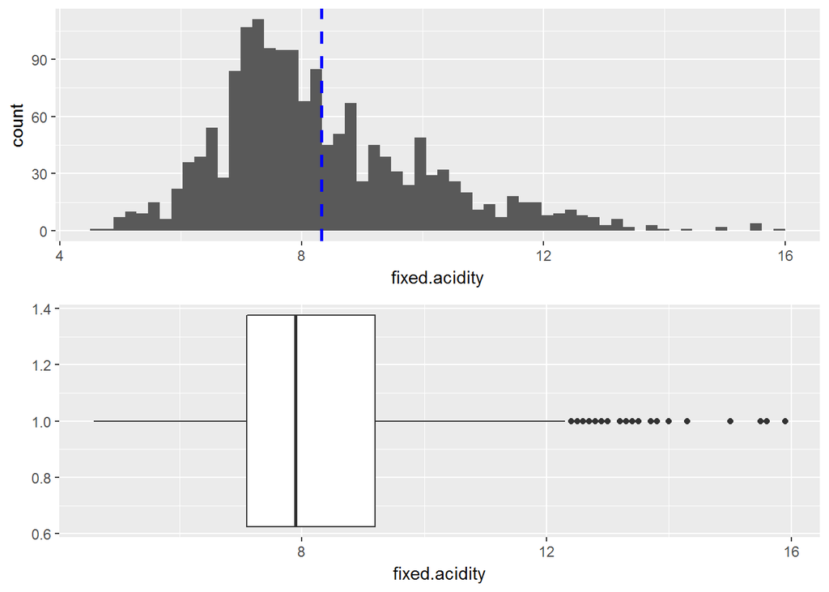

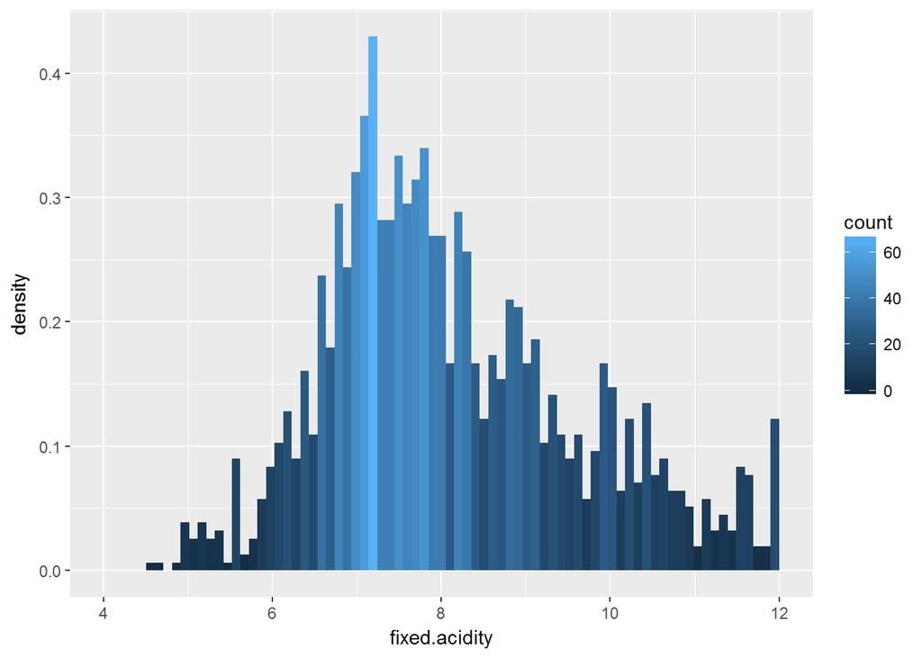

```
##    Min. 1st Qu.  Median    Mean 3rd Qu.    Max.
##    4.60    7.10    7.90    8.32    9.20   15.90
```

```
## Outliers are greater than: 12.35
```

```
## Extreme outliers are greater than: 15.5
```

```
## The standard deviation is: 1.741096
```

```
## Extreme outliers for fixed.acidity: 5
```

```
## The standard deviation without any outliers: 1.513582
```

The data for fixed.acidity is skewed to the right, with half of the wines having fixed.acidity between 7 and 9. There are several outliers of which five are extreme. It seems that there are certain fixed.acidity levels that are more common, these are suggested by the presence of isolated higher peaks and gaps more noticeable when the binwidth is reduced (as in the density histogram).

#### Volatile acidity

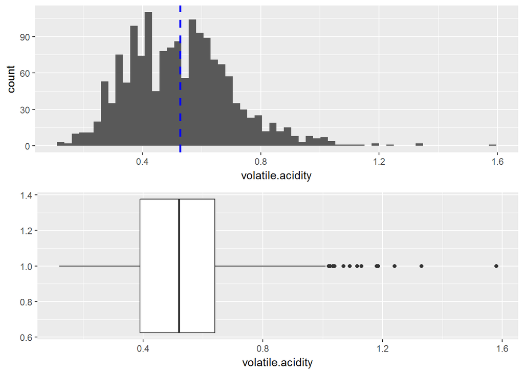

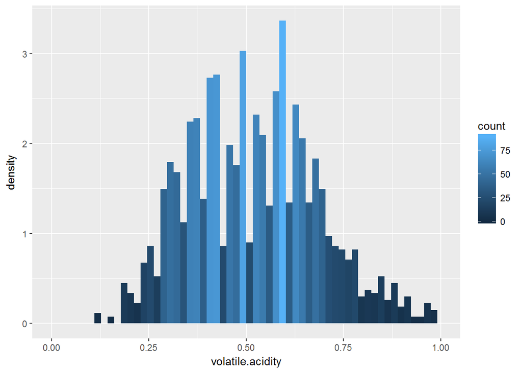

```
##    Min. 1st Qu.  Median    Mean 3rd Qu.    Max.
##  0.1200  0.3900  0.5200  0.5278  0.6400  1.5800
```

```
## Outliers are greater than: 1.015
```

```
## Extreme outliers are greater than: 1.39
```

```
## The standard deviation is: 0.1790597
```

```
## Extreme outliers for volatile.acidity: 1
```

```
## The standard deviation without outliers: 0.1665809
```

#### Citric acid

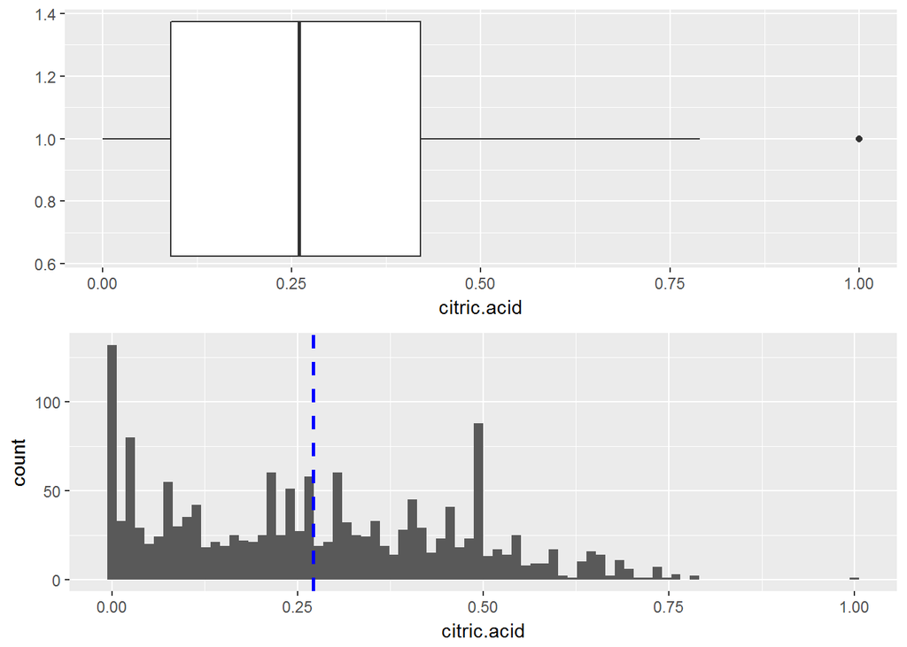

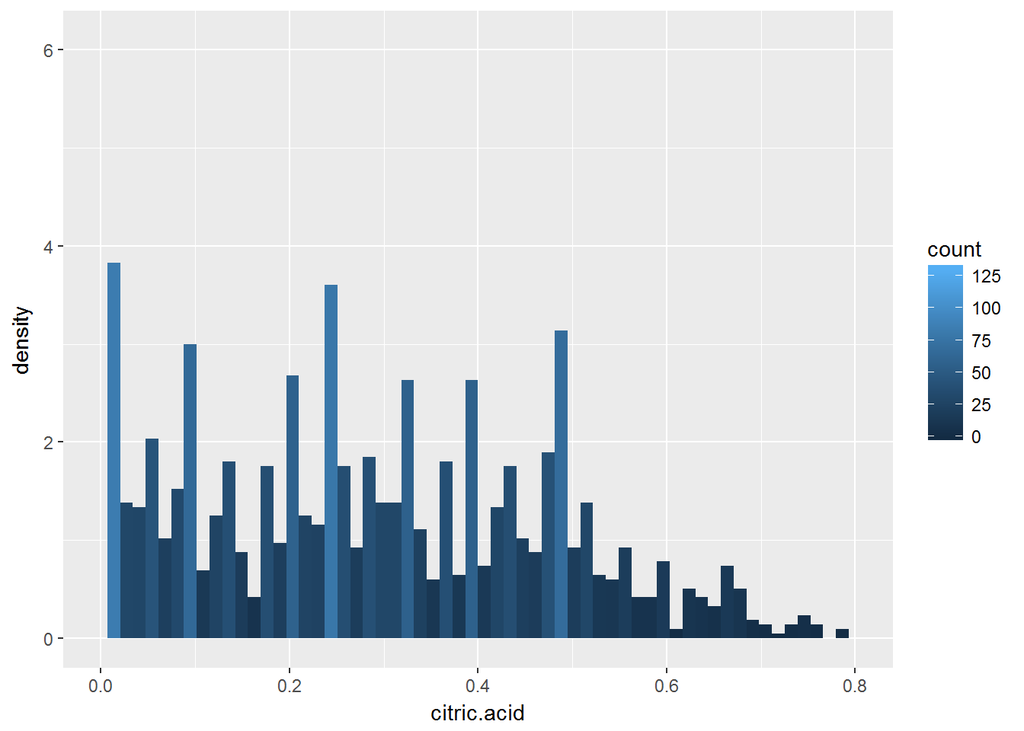

```
##    Min. 1st Qu.  Median    Mean 3rd Qu.    Max.
##   0.000   0.090   0.260   0.271   0.420   1.000
```

```
## Outliers are greater than: 0.915
```

```
## Extreme outliers are greater than: 1.41
```

```
## The standard deviation is: 0.1948011
```

The distribution of the citric.acid content is multimodal. Most of the data has citric.acid less than 0.5. There are several peaks, the highest corresponds to wines with no citric.acid content. There is also an outlier that corresponds to the value 1.

#### Residual sugar

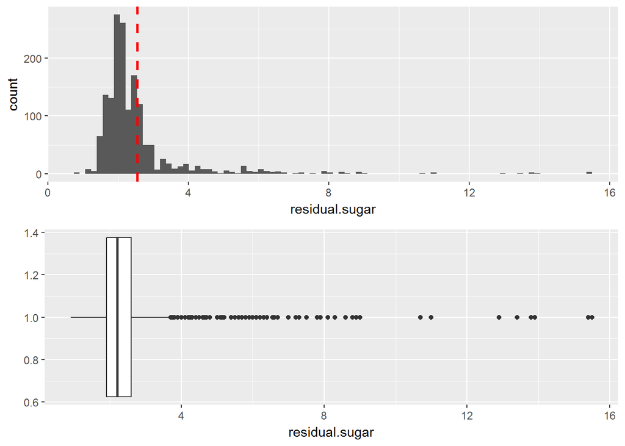

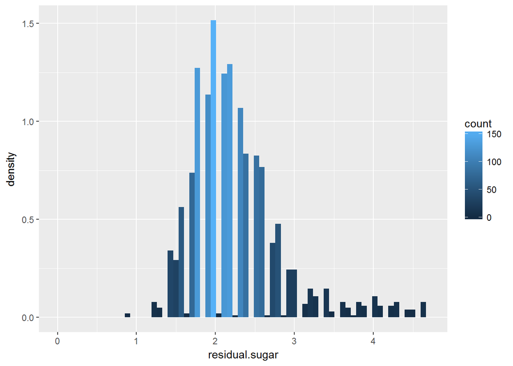

```
##    Min. 1st Qu.  Median    Mean 3rd Qu.    Max.
##   0.900   1.900   2.200   2.539   2.600  15.500
```

```
## Outliers are greater than: 3.65
```

```
## Extreme outliers are greater than: 4.7
```

```
## The standard deviation is: 1.409928
```

```
## Extreme outliers for residual.sugar: 88
```

```
## The standard deviation without any outliers: 0.4491415
```

The data for residual sugar has a very long right tail. Outside this tail, the data shows a bimodal distribution in the frequency histogram. Most of the wines have residual sugar of up to 2.6 but the maximum value is 15.5, so we see a large spread of values. To plot the density histogram I adjusted the x-axis limits to exclude the extreme outliers. There are numerous gaps and the distribution is still right skewed. There are 88 extreme outliers in this case. The main data, without counting the outliers, has a relatively small spread.

#### Sugar levels

```
Create a factor variable sugar_levels:

    low_sugar       residual.sugar <= median
    high_sugar      median < residual.sugar < mild_outlier_value
    extra_sugar     mild_outlier_value < residual.sugar
```

```
##
## extra_sugar  high_sugar   low_sugar
##         155         561         883
```

#### Chlorides

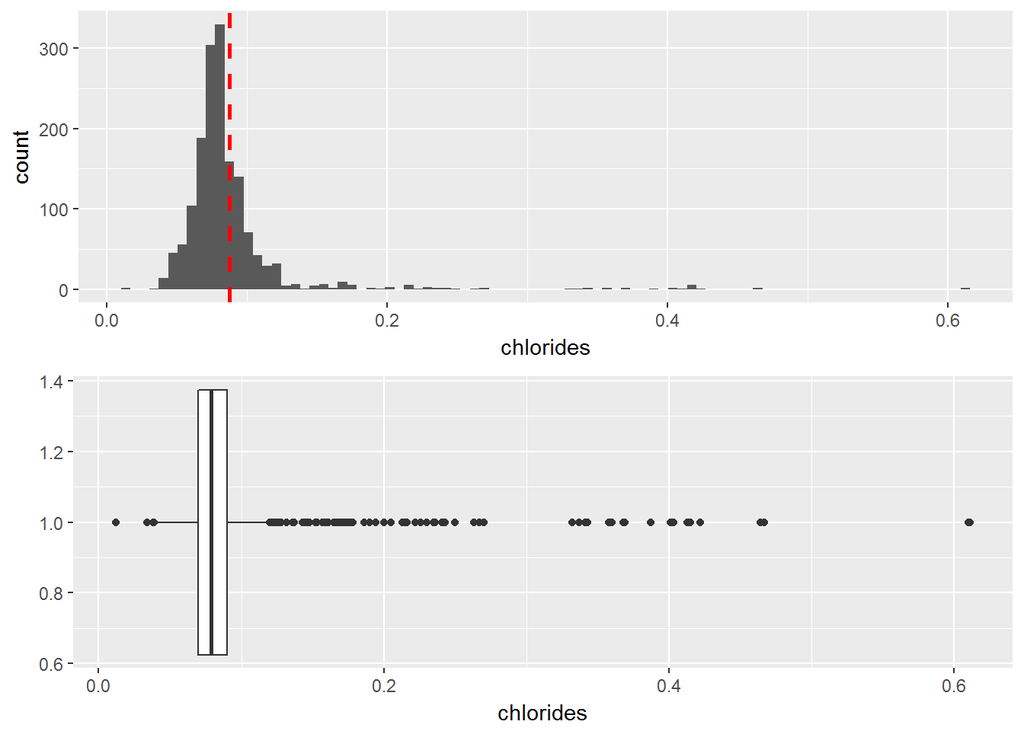

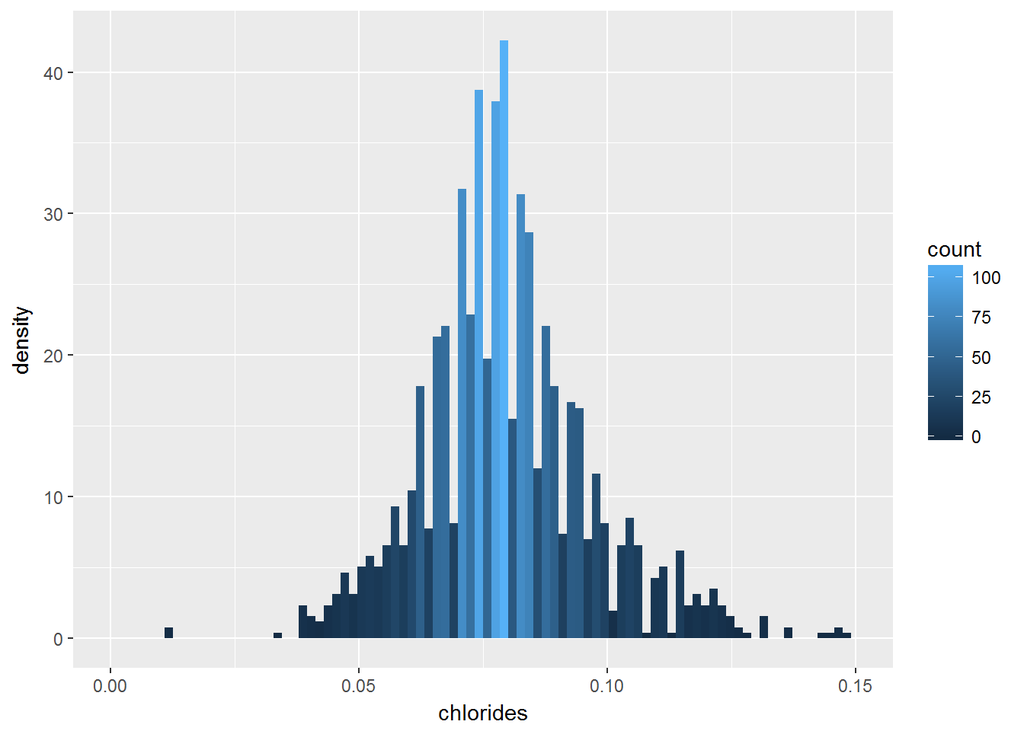

```
##    Min. 1st Qu.  Median    Mean 3rd Qu.    Max.
## 0.01200 0.07000 0.07900 0.08747 0.09000 0.61100
```

```
## Outliers are smaller than: 0.04 and greater than: 0.12
```

```
## Extreme outliers are greater than: 0.15
```

```
## The standard deviation is: 0.0470653
```

```
## Extreme outliers for chlorides: 67
```

```
## The standard deviation without any outliers: 0.01527472
```

The frequency histogram for chlorides has a long tail to the right. The majority of the data is comprised between 0.07 and 0.09. We see a large spread of values, up to 0.6. There are many outliers, some of them to the left of the mean. Specifically, there are 67 extreme outliers. For the density histogram, I zoomed into the main data, the distribution is almost normal, slightly right skewed.

#### Free sulfur dioxide

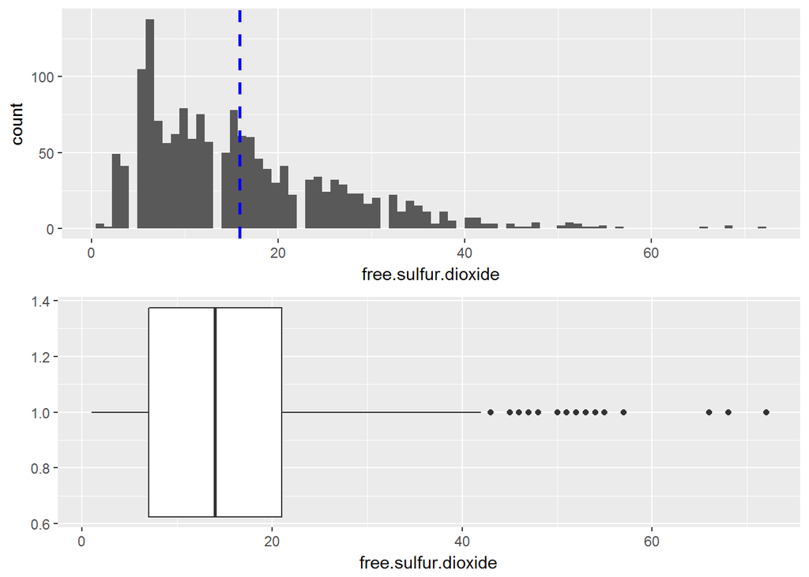

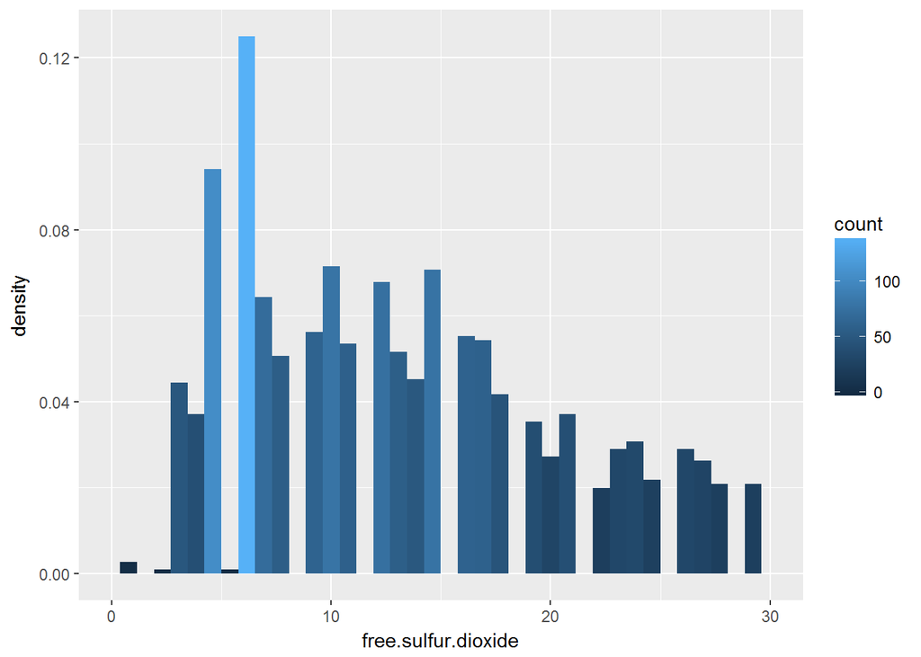

```
##    Min. 1st Qu.  Median    Mean 3rd Qu.    Max.
##    1.00    7.00   14.00   15.87   21.00   72.00
```

```
## Outliers are greater than: 42
```

```
## Extreme outliers are greater than: 63
```

```
## The standard deviation is: 10.46016
```

```
## Extreme outliers for free sulfur dioxide: 4
```

```
## The standard deviation without any outliers: 9.226586
```

The frequency diagram for free sulfur dioxide is right skewed with a long tail, several gaps and two very high peaks. Half of the wines have free sulfur dioxide between 7 and 21. There are several outliers, four of which are extreme. The highest amount of 72 and a large standard deviation indicate a wide spread of values. In the density histogram, I take a second look at the wines with free sulfur dioxide less than 30. The two high peaks are noticeable and the gaps suggest that there are certain values that are more common. A small number of wines have very low amounts of free sulfur dioxide.

#### Total sulfur dioxide

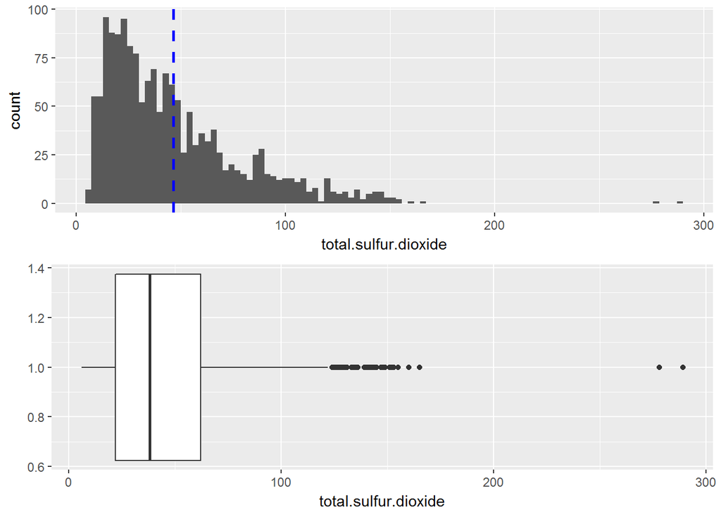

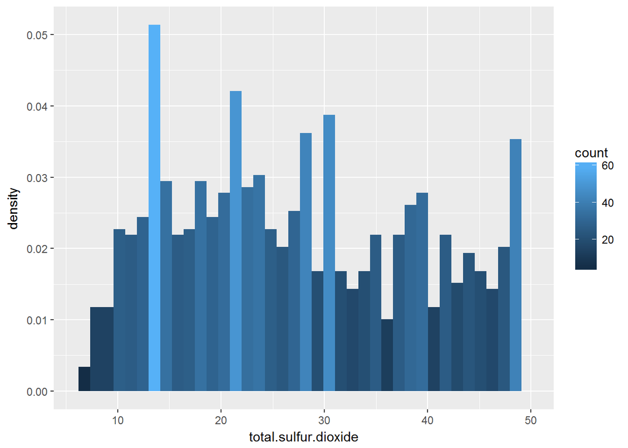

```
##    Min. 1st Qu.  Median    Mean 3rd Qu.    Max.
##    6.00   22.00   38.00   46.47   62.00  289.00
```

```
## Outliers are greater than: 122
```

```
## Extreme outliers are greater than: 182
```

```
## The standard deviation is: 32.89532
```

```
## Extreme outliers for total sulfur dioxide: 2
```

```
## The standard deviation without any outliers: 27.2148
```

The shape of the frequency histogram for the total sulfur dioxide is right skewed, with a rather steep left hand side. Most of the wines have total sulfur dioxide between 6 and 62, but there is a wide spread up to values of almost 300. There are lots of outliers, the two extreme outliers have very large values and I wonder if those records are accurate. In the density histogram, I take a closer look at the distribution that lies to the left of the mean. This subset of the data has a multimodal distribution with several quite high peaks.

#### Density

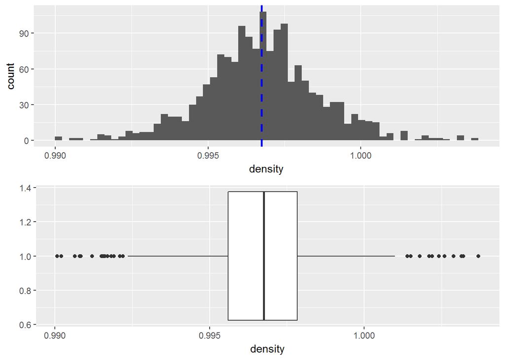

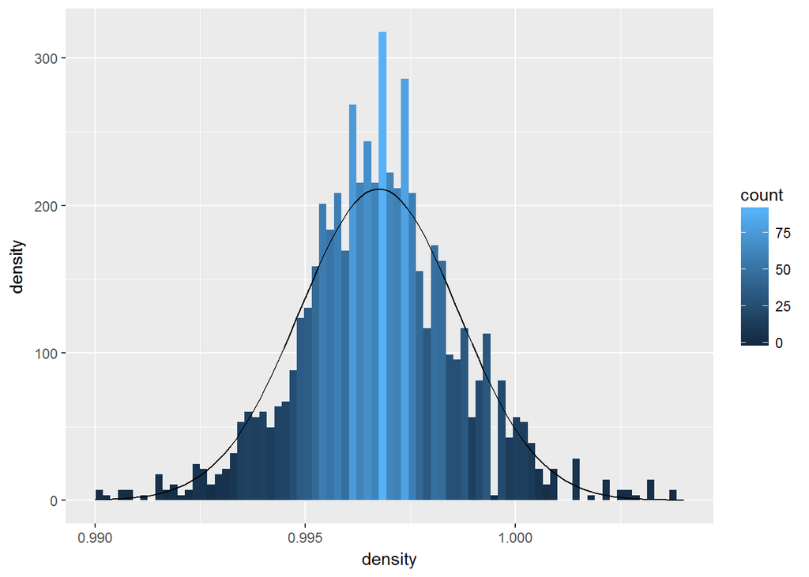

```
##    Min. 1st Qu.  Median    Mean 3rd Qu.    Max.
##  0.9901  0.9956  0.9968  0.9967  0.9978  1.0037
```

```
## Outliers are smaller than: 0.9922475 and greater than: 1.001187
```

```
## Extreme outliers are greater than: 1.00454
```

```
## The standard deviation is: 0.001887334
```

```
## Extreme outliers for density: 0
```

The data for density is interesting, its distribution is normal, with values ranging in a small interval from 0.9901 to 1.0037. There are outliers on both sides, as it can be easily noticed from the boxplot, but none of these outliers are extreme. A normal distribution curve overlaps nicely with the density histogram. There are several peaks and gaps.

#### pH

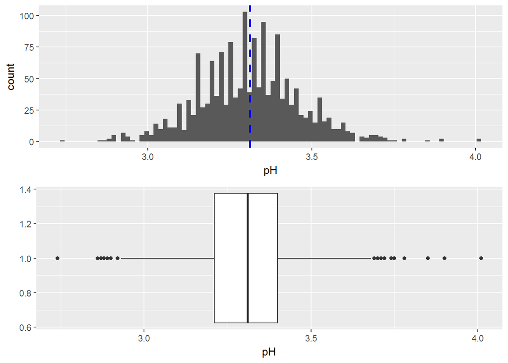

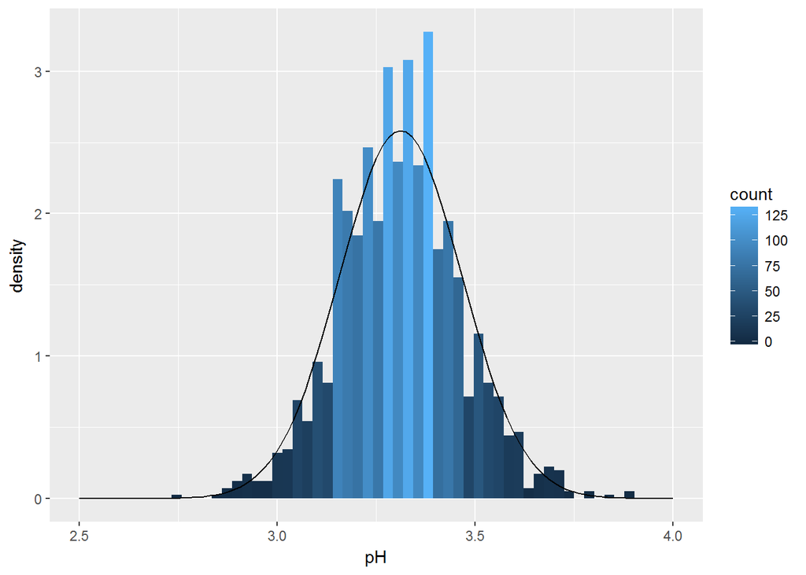

```
##    Min. 1st Qu.  Median    Mean 3rd Qu.    Max.
##   2.740   3.210   3.310   3.311   3.400   4.010
```

```
## Outliers are greater than: 3.685
```

```
## Extreme outliers are smaller than 2.64 and greater than: 3.97
```

```
## The standard deviation is: 0.1543865
```

```
## Extreme outliers for pH: 2
```

The distribution for pH is normal, although there are several high peaks that are almost equidistantly distributed. The values range from 2.74 to about 4, with half of the data having pH of about 3.2 to 3.4. The boxplot indicates the presence of outliers, two of which are extreme. The normal distribution curve fits well with the density diagram.

#### pH levels

```
Create a factor variable for the pH levels, based on quartiles:

    low_pH           lowest 25% of pH values
    mod_pH           25%-50% of pH values
    mod.high_pH      50%-75% of pH values
    high_pH          highest 25% of pH values
```

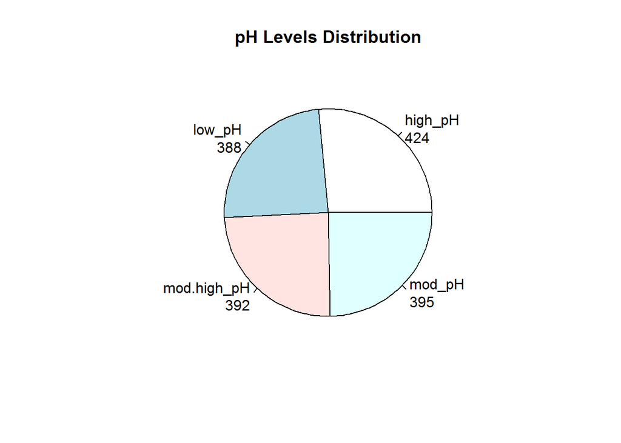

#### Sulphates

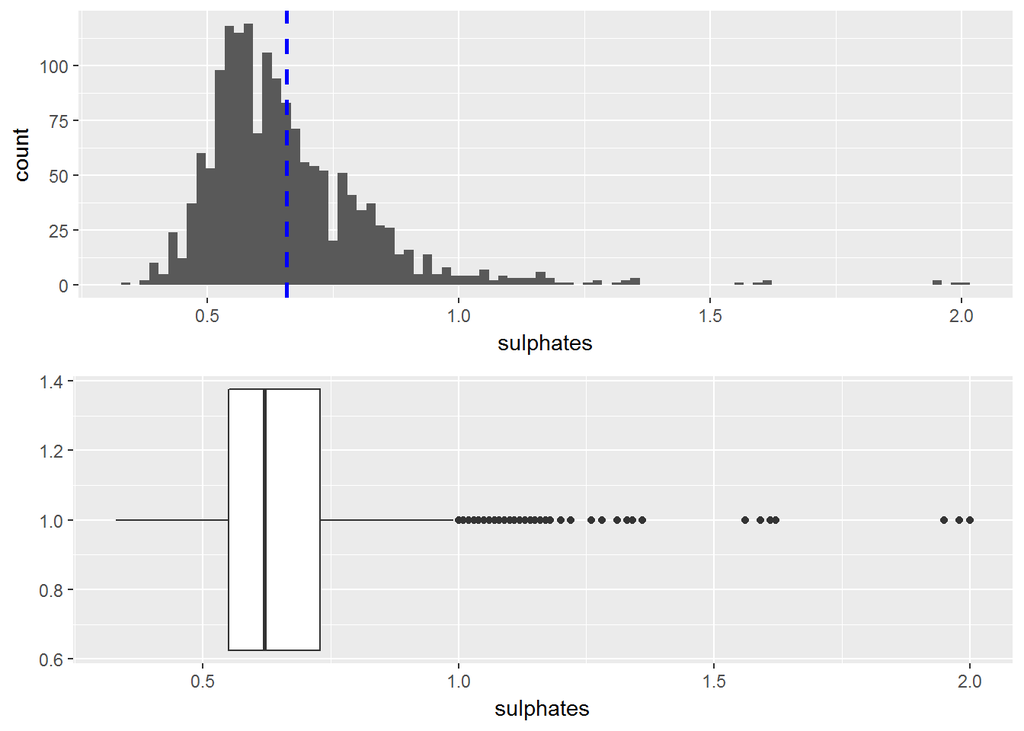

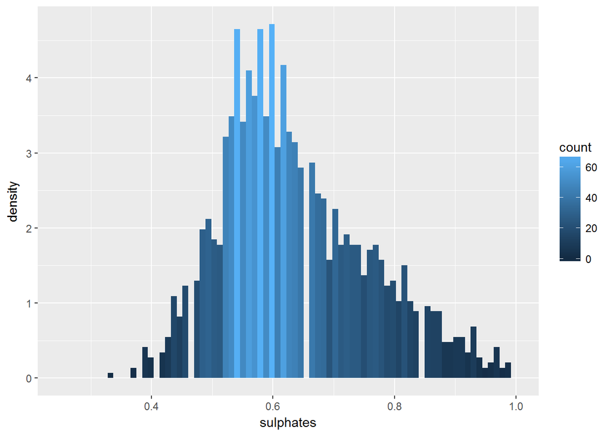

```
##    Min. 1st Qu.  Median    Mean 3rd Qu.    Max.
##  0.3300  0.5500  0.6200  0.6581  0.7300  2.0000
```

```
## Outliers are greater than: 1
```

```
## Extreme outliers are greater than: 1.27
```

```
## The standard deviation is: 0.169507
```

```
## Extreme outliers for sulphates: 16
```

```
## The standard deviation without any outliers: 0.1209633
```

The sulphates have a skewed distribution, with a very long tail to the right due to the numerous outliers. Most values fall between 0.55 and 0.73. There are 16 extreme outliers, that correspond to values as large as 2. In the density histogram, I look at the main bulk of data, and the distribution is skewed to the right. There are several high peaks and a few gaps.

#### Alcohol

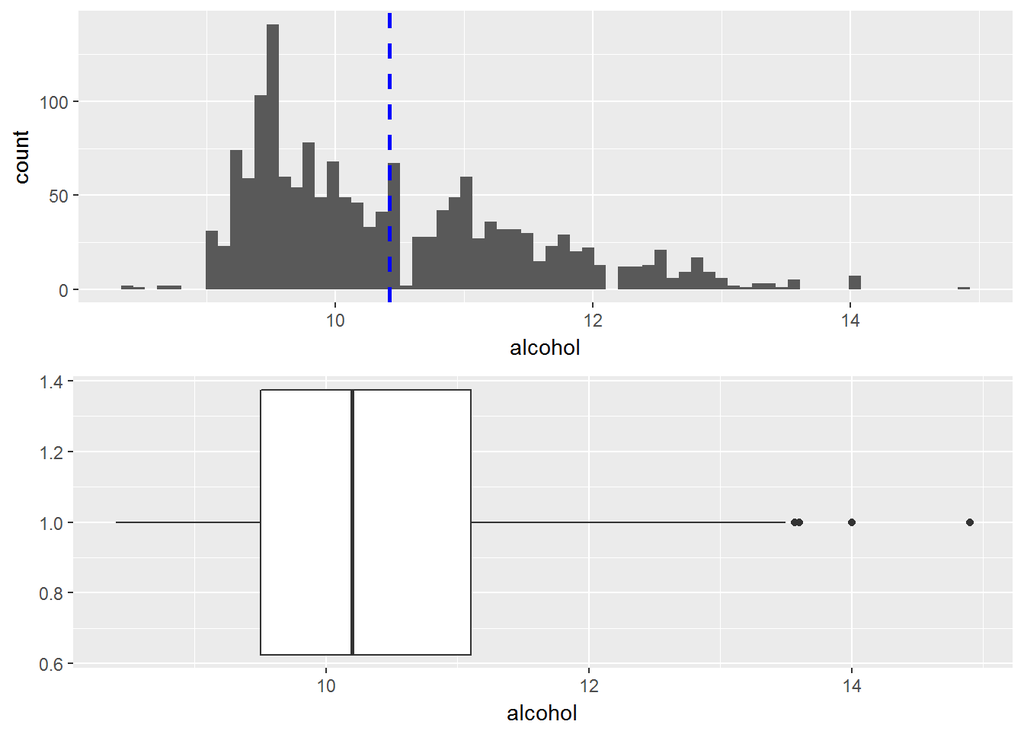

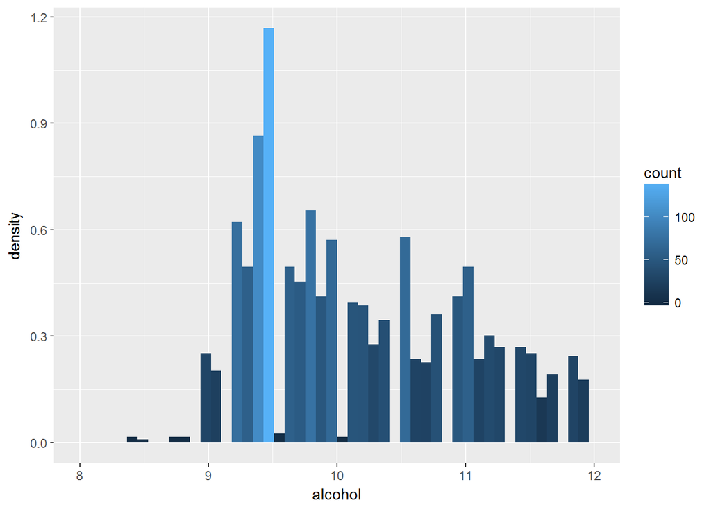

```
##    Min. 1st Qu.  Median    Mean 3rd Qu.    Max.
##    8.40    9.50   10.20   10.42   11.10   14.90
```

```
## Outliers are greater than: 13.5
```

```
## Extreme outliers are greater than: 15.9
```

```
## The standard deviation is: 1.065668
```

```
## Extreme outliers for alcohol: 0
```

```
## The standard deviation without any outliers: 1.021412
```

The alcohol content does not vary too much, it takes values in the interval from 8.4 to 14.9, with most of the wines having at alcohol of at most 11.10. The distribution is right skewed. Not too many outliers in this case, no extreme outliers. Both the frequency and the density histograms indicate the presence of a couple of very high peaks for wines with lower alcohol content. Several gaps are also present.

#### Alcohol levels

```
Create a new factor variable for alcohol levels, using quartiles:

        low_alcohol         lowest 25% of alcohol levels
        mod.low_alcohol     25%-50% of alcohol levels
        mod.high_alcohol    50%-75% of alcohol levels
        high_alcohol        75% to max alcohol levels
```

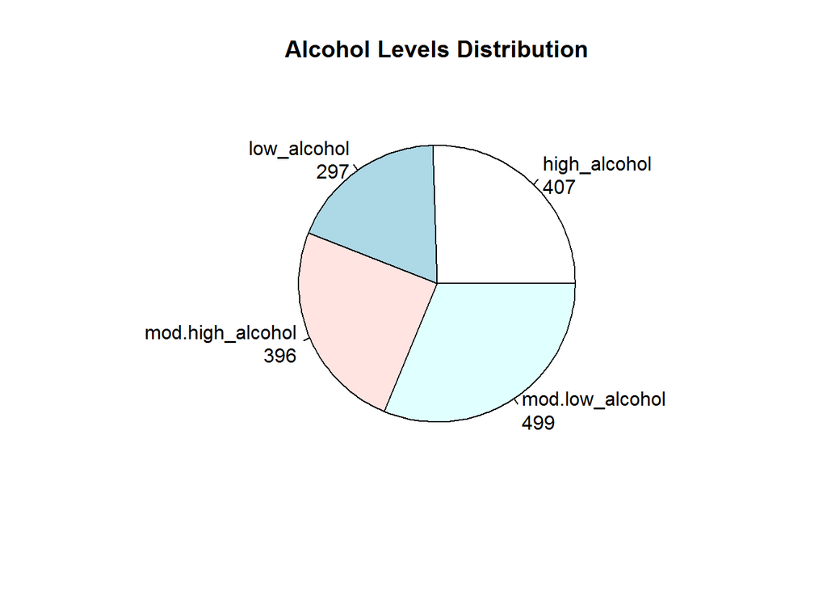

#### Quality

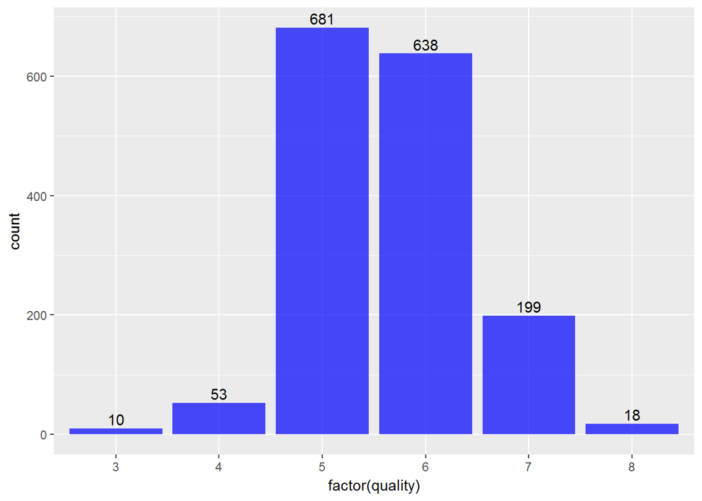

The quality is the only categorical variable we have analyzed so far. The wines in this dataset have quality ranging from 3 to 8, in increments of 1. From the bar chart we see that the vast majority (1319 samples out of 1599 samples) were assigned quality grades of 5 or 6, thus more or less average quality.

# Univariate Analysis

### What is the structure of your dataset?

The dataset consists of 1599 samples of a certain variety of red wine, ‘Vinho Verde’, from northern Portugal. Each sample is denoted by a label X, and it is described by 11 physicochemical properties (numerical variables). A quality that ranges from 3 to 8 is also associated to the sample. The dataset is tidy and has no missing values.

Some of my initial observations:

- some of the attributes (such as residual sugar, chlorides, free and total sulfur dioxide) have wide ranges of values;
- the density and the pH do not vary too much among these samples;
- the mean alcohol level of 10.42% is lower than the usual alcohol levels found in red wines;
- the quality varies between 0 and 10, but in this dataset it takes only values between 3 and 8, with less than 20 wines with quality rating of 8, most of the wines have average quality ratings.

### What is/are the main feature(s) of interest in your dataset?

The main feature of interest is the quality, in particular how the pysicochemical attributes influence the quality of the sample. I am also interested in related questions, such as if sweeter wines or if higher alcohol percentage wines receive better ratings. Also, I think it would be informative to see what other relations could be found among the physicochemical properties of the wine.

### What other features in the dataset do you think will help support your investigation into your feature(s) of interest?

At this point, without looking at specific statistics I think that the alcohol, the residual sugar and the pH would be significant in determining the quality of the wine.

In [Cortez et al., 2009] a model to predict the quality of the wine is built. I find it intriguing that this model gives sulphates as the main attribute that would influence the ratings of the wine. I plan to look into the relation between sulphates and quality.

### Did you create any new variables from existing variables in the dataset?

Yes I created three factor variables: sugar.levels, pH.levels and alcohol.levels.

The sugar.levels variable uses the median to divide the wines in two groups (low_sugar and high_sugar). The numerous extreme outliers for residual sugar are given the extra.sugar level.

The other two categorical variables, pH.levels and alcohol.levels, divide the wines into four groups each, based on the 5 numbers statistics for pH and alcohol respectively.

### Of the features you investigated, were there any unusual distributions? Did you perform any operations on the data to tidy, adjust, or change the form of the data? If so, why did you do this?

First I will discuss the following attributes: fixed.acidity, volatile.acidity, residual.sugar, chlorides, free sulfur.dioxide, total sulfur.dioxide, sulphates and alcohol. All these distributions are skewed to the right, with numerous outliers. I find it interesting that in most cases (except for chlorides) most of the outliers are located in the tail of the distribution, thus they tend to have larger values than average of the analyzed chemical. Although each distribution shows the presence of the outliers, the number of extreme outliers is usually small (less than 5). However, there are three exceptions: residual.sugar (88 extreme outliers), chlorides (67 extreme outliers) and sulphates (16 extreme outliers).

Among the remaining attributes, two of the distributions are normal, density and pH. This is quite unusual for real sets of data.

Regarding the quality. I notice that very few wines receive a grading of 8 (about 18) and none are rated as 9 or 10. At the other end there are only 63 samples with quality 3 or 4. This leaves us with the vast majority of wines having an average quality. Thus, I think that it will be harder to distinguish among the attributes which ones have a significant impact on the quality.

The dataset is already tidy. I did form subsets of extreme outliers for residual.sugar, chlorides and sulfates. I also created subsets of the data that do not contain these extreme outliers. I plan to investigate further these sets of extreme outliers, to determine if there are unusually good or unusually bad wines among them.

I created density plots for each of the numerical variables, in which I also adjusted the x-axis limits, in order to eliminate some of the tails and get a better look at the main data.

# Bivariate Plots Section

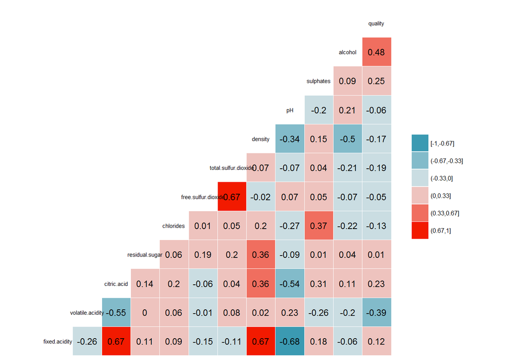

The main feature of interest is the quality. From the correlation matrix I notice that alcohol has strongest correlation of 0.48 with quality, followed by sulphates (correlation 0.25) and citric acid (correlation of 0.23). Also volatile.acidity has negative stronger correlation coefficient (of -0.39) with quality. I am surprised to learn that the residual sugar and the pH have very small influence on quality.

### Quality and Various Attributes

The boxplots below show how various attributes behave when divided into subsets based on quality. A line connecting the medians is added and the numerical values of these median values are included in most graphs.

#### Quality and Volatile Acidity

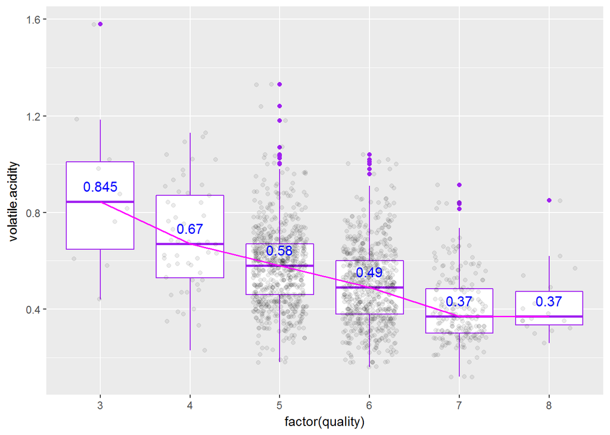

```
##
##  Pearson's product-moment correlation
##
## data:  rwine$quality and rwine$volatile.acidity
## t = -16.954, df = 1597, p-value < 2.2e-16
## alternative hypothesis: true correlation is not equal to 0
## 95 percent confidence interval:
##  -0.4313210 -0.3482032
## sample estimates:
##        cor
## -0.3905578
```

```
## Volatile acidity descriptive statistics for quality = 3
```

```
##    Min. 1st Qu.  Median    Mean 3rd Qu.    Max.
##  0.4400  0.6475  0.8450  0.8845  1.0100  1.5800
```

```
## Volatile descriptive statistics for quality = 4
```

```
##    Min. 1st Qu.  Median    Mean 3rd Qu.    Max.
##   0.230   0.530   0.670   0.694   0.870   1.130
```

```
## Volatile acidity descriptive statistics for quality = 5
```

```
##    Min. 1st Qu.  Median    Mean 3rd Qu.    Max.
##   0.180   0.460   0.580   0.577   0.670   1.330
```

```
## Volatile acidity descriptive statistics for quality = 6
```

```
##    Min. 1st Qu.  Median    Mean 3rd Qu.    Max.
##  0.1600  0.3800  0.4900  0.4975  0.6000  1.0400
```

```
## Volatile acidity descriptive statistics for quality = 7
```

```
##    Min. 1st Qu.  Median    Mean 3rd Qu.    Max.
##  0.1200  0.3000  0.3700  0.4039  0.4850  0.9150
```

```
## Volatile acidity descriptive statistics for quality = 8
```

```
##    Min. 1st Qu.  Median    Mean 3rd Qu.    Max.
##  0.2600  0.3350  0.3700  0.4233  0.4725  0.8500
```

The trend is clear from both the graphical description and the statistics performed on the data. The volatile acidity decreases with the quality, from quality 3 to 7. The better wines with quality 7 and 8 have similar levels of volatile acidity. Most of the outliers are concentrated at levels 5 and 6, where the majority of the samples are found.

#### Quality and Citric Acid

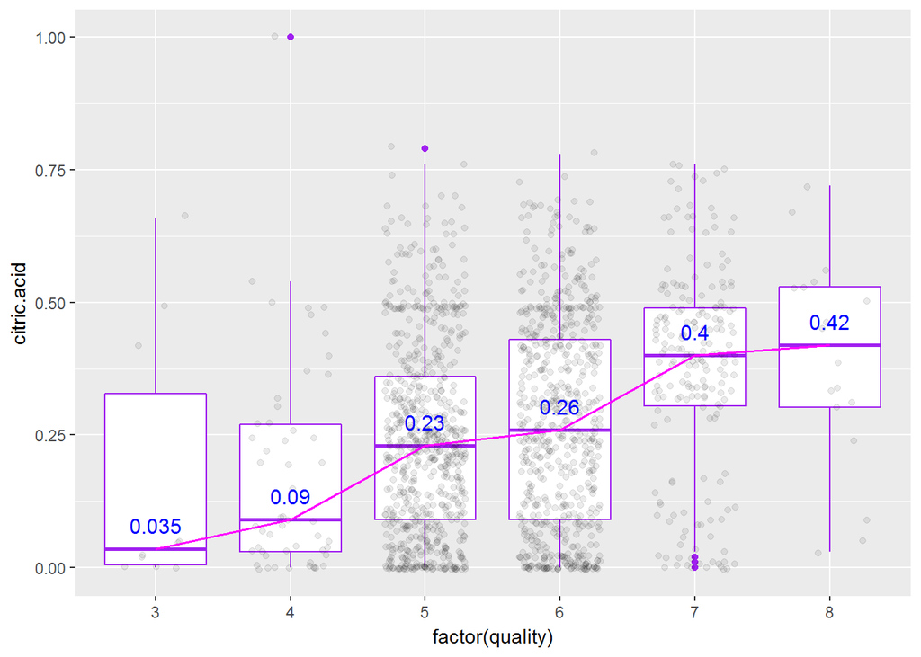

```
##
##  Pearson's product-moment correlation
##
## data:  rwine$quality and rwine$citric.acid
## t = 9.2875, df = 1597, p-value < 2.2e-16
## alternative hypothesis: true correlation is not equal to 0
## 95 percent confidence interval:
##  0.1793415 0.2723711
## sample estimates:
##       cor
## 0.2263725
```

```
## Citric acid descriptive statistics for quality = 3
```

```
##    Min. 1st Qu.  Median    Mean 3rd Qu.    Max.
##  0.0000  0.0050  0.0350  0.1710  0.3275  0.6600
```

```
## Citric acid descriptive statistics for quality = 4
```

```
##    Min. 1st Qu.  Median    Mean 3rd Qu.    Max.
##  0.0000  0.0300  0.0900  0.1742  0.2700  1.0000
```

```
## Citric acid descriptive statistics for quality = 5
```

```
##    Min. 1st Qu.  Median    Mean 3rd Qu.    Max.
##  0.0000  0.0900  0.2300  0.2437  0.3600  0.7900
```

```
## Citric acid descriptive statistics for quality = 6
```

```
##    Min. 1st Qu.  Median    Mean 3rd Qu.    Max.
##  0.0000  0.0900  0.2600  0.2738  0.4300  0.7800
```

```
## Citric acid descriptive statistics for quality = 7
```

```
##    Min. 1st Qu.  Median    Mean 3rd Qu.    Max.
##  0.0000  0.3050  0.4000  0.3752  0.4900  0.7600
```

```
## Citric acid descriptive statistics for quality = 8
```

```
##    Min. 1st Qu.  Median    Mean 3rd Qu.    Max.
##  0.0300  0.3025  0.4200  0.3911  0.5300  0.7200
```

The citric acid increases from wines of quality 3 to the wines of quality 8. Furthermore we see a sharp increase in the median value from 0.26 (qualities 5 and 6) to 0.40 (qualities 7 and 8). The better wines have citric acid values that vary less than those in the average quality wines.

#### Quality and Residual Sugar

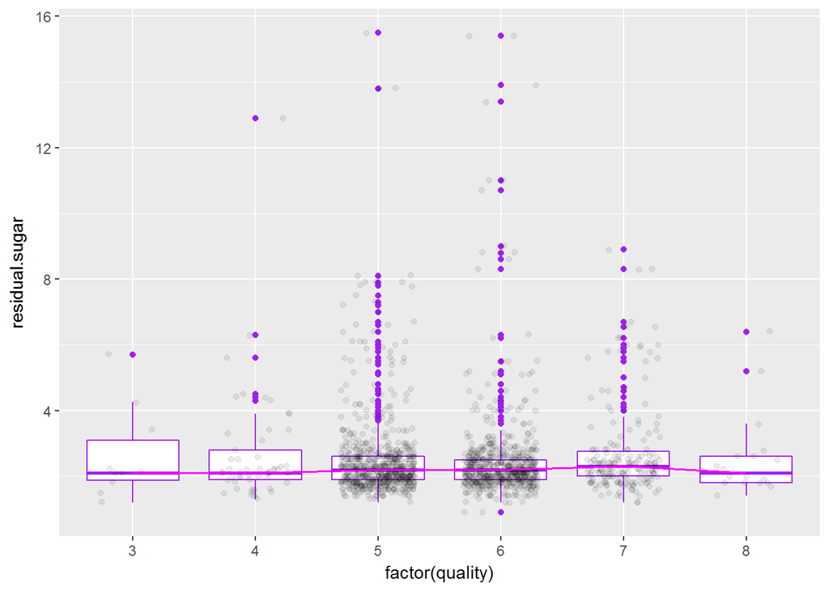

```
##
##  Pearson's product-moment correlation
##
## data:  rwine$quality and rwine$residual.sugar
## t = 0.5488, df = 1597, p-value = 0.5832
## alternative hypothesis: true correlation is not equal to 0
## 95 percent confidence interval:
##  -0.03531327  0.06271056
## sample estimates:
##        cor
## 0.01373164
```

```
## Residual sugar descriptive statistics for quality = 3
```

```
##    Min. 1st Qu.  Median    Mean 3rd Qu.    Max.
##   1.200   1.875   2.100   2.635   3.100   5.700
```

```
## Residual sugar descriptive statistics for quality = 4
```

```
##    Min. 1st Qu.  Median    Mean 3rd Qu.    Max.
##   1.300   1.900   2.100   2.694   2.800  12.900
```

```
## Residual sugar descriptive statistics for quality = 5
```

```
##    Min. 1st Qu.  Median    Mean 3rd Qu.    Max.
##   1.200   1.900   2.200   2.529   2.600  15.500
```

```
## Residual sugar descriptive statistics for quality = 6
```

```
##    Min. 1st Qu.  Median    Mean 3rd Qu.    Max.
##   0.900   1.900   2.200   2.477   2.500  15.400
```

```
## Residual sugar descriptive statistics for quality = 7
```

```
##    Min. 1st Qu.  Median    Mean 3rd Qu.    Max.
##   1.200   2.000   2.300   2.721   2.750   8.900
```

```
## Residual sugar descriptive statistics for quality = 8
```

```
##    Min. 1st Qu.  Median    Mean 3rd Qu.    Max.
##   1.400   1.800   2.100   2.578   2.600   6.400
```

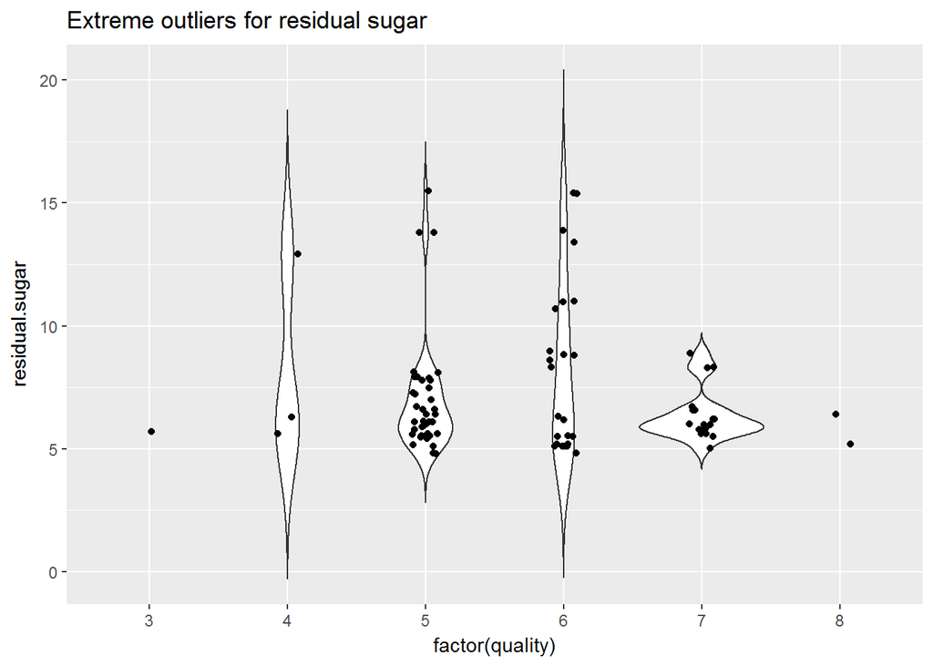

The residual sugar values seem to be quite evenly distributed among the quality levels, as long as we do not take into account the outliers. Most of these outliers lie in the groups of quality 5, 6 and 7, as can be easily observed in the violin plot. The distribution of the extreme outliers does not indicate that the extra sugar is a deciding factor in determining the wine quality. The concentration of outliers in the average quality categories might just be due to the fact that these groups are more numerous.

#### Quality and Chlorides

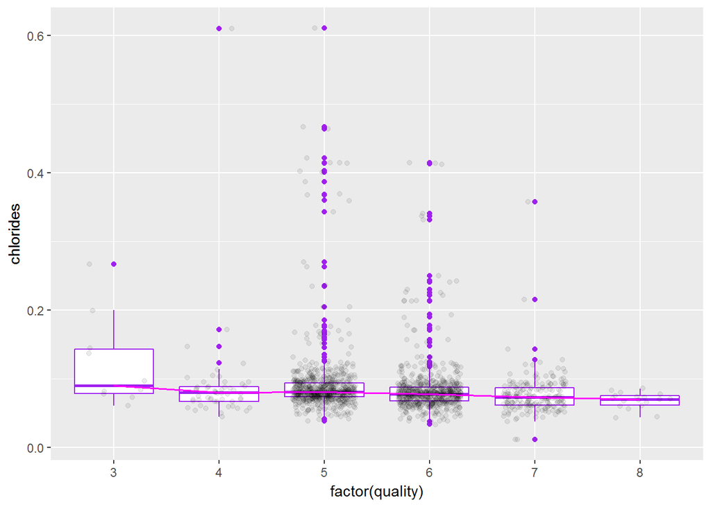

```
##
##  Pearson's product-moment correlation
##
## data:  rwine$quality and rwine$chlorides
## t = -5.1948, df = 1597, p-value = 2.313e-07
## alternative hypothesis: true correlation is not equal to 0
## 95 percent confidence interval:
##  -0.17681041 -0.08039344
## sample estimates:
##        cor
## -0.1289066
```

```
## Chlorides descriptive statistics for quality = 3
```

```
##    Min. 1st Qu.  Median    Mean 3rd Qu.    Max.
##  0.0610  0.0790  0.0905  0.1225  0.1430  0.2670
```

```
## Chlorides descriptive statistics for quality = 4
```

```
##    Min. 1st Qu.  Median    Mean 3rd Qu.    Max.
## 0.04500 0.06700 0.08000 0.09068 0.08900 0.61000
```

```
## Chlorides descriptive statistics for quality = 5
```

```
##    Min. 1st Qu.  Median    Mean 3rd Qu.    Max.
## 0.03900 0.07400 0.08100 0.09274 0.09400 0.61100
```

```
## Chlorides descriptive statistics for quality = 6
```

```
##    Min. 1st Qu.  Median    Mean 3rd Qu.    Max.
## 0.03400 0.06825 0.07800 0.08496 0.08800 0.41500
```

```
## Chlorides descriptive statistics for quality = 7
```

```
##    Min. 1st Qu.  Median    Mean 3rd Qu.    Max.
## 0.01200 0.06200 0.07300 0.07659 0.08700 0.35800
```

```
## Chlorides descriptive statistics for quality = 8
```

```
##    Min. 1st Qu.  Median    Mean 3rd Qu.    Max.
## 0.04400 0.06200 0.07050 0.06844 0.07550 0.08600
```

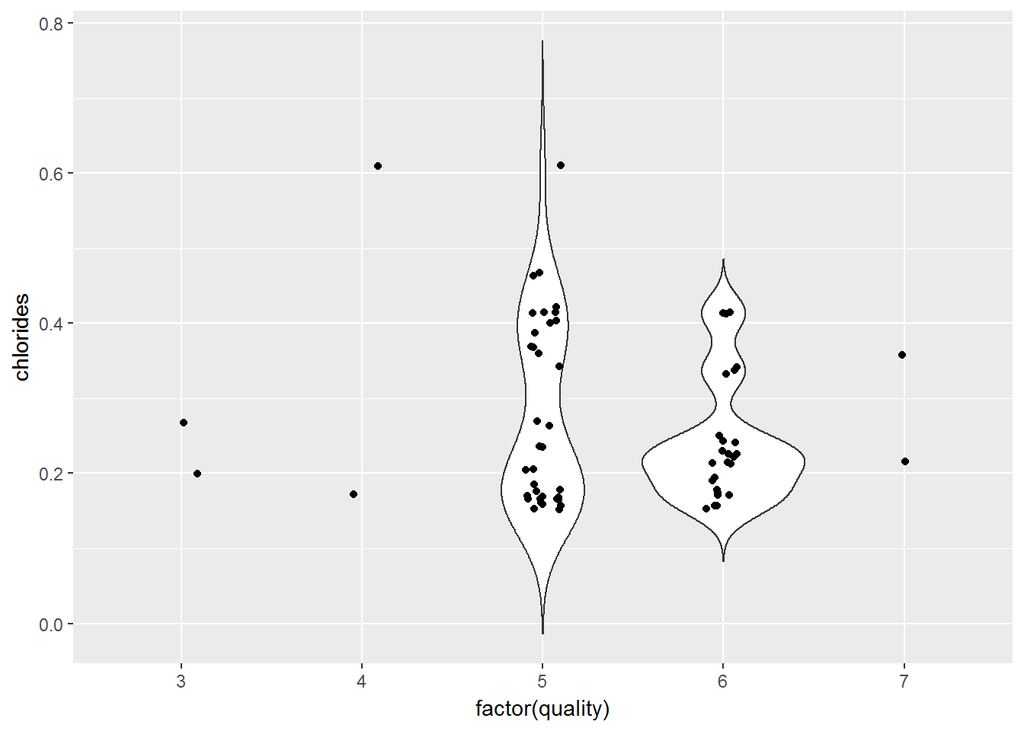

The chlorides level decreases with the quality. The interquantile range decreases significantly with quality. Chlorides is one of the attributes with a large number of extreme outliers, which are mostly distributed among the wines of qualities 5 and 6. Again, it is possible that the concentration of outliers in the categories 5 and 6 might be just due to the fact that these groups are larger.